# Basic Exercises on Data Importing - Understanding - Manipulating - Analysis - Visualization

## Section-1: The pupose of the below exercises (1-7) is to create dictionary and convert into dataframes, how to diplay etc...

## The below exercises required to create data

### 1. Import the necessary libraries (pandas, numpy, datetime, re etc)

```python
import pandas as pd
import numpy as np
import matplotlib.pyplot as plt
import datetime as dt
import seaborn as sns
import re

# set the graphs to show in the jupyter notebook
%matplotlib inline

# set seabor graphs to a better style
sns.set(style="ticks")
```

### 2. Run the below line of code to create a dictionary and this will be used for below exercises

```python
raw_data = {"name": ['Bulbasaur', 'Charmander','Squirtle','Caterpie'],
            "evolution": ['Ivysaur','Charmeleon','Wartortle','Metapod'],
            "type": ['grass', 'fire', 'water', 'bug'],
            "hp": [45, 39, 44, 45],
            "pokedex": ['yes', 'no','yes','no']
            }
```

```python
### 3. Assign it to a object called pokemon and it should be a pandas DataFrame
```

```python
pokemon=pd.DataFrame(raw_data)
pokemon
```

|  | name | evolution | type | hp | pokedex |
| --- | --- | --- | --- | --- | --- |
| 0 | Bulbasaur | Ivysaur | grass | 45 | yes |
| 1 | Charmander | Charmeleon | fire | 39 | no |
| 2 | Squirtle | Wartortle | water | 44 | yes |
| 3 | Caterpie | Metapod | bug | 45 | no |

### 4. If the DataFrame columns are in alphabetical order, change the order of the columns as name, type, hp, evolution, pokedex

```python
pokemon= pokemon[['name', 'type','hp','evolution','pokedex']]
pokemon
```

|  | name | type | hp | evolution | pokedex |
| --- | --- | --- | --- | --- | --- |
| 0 | Bulbasaur | grass | 45 | Ivysaur | yes |
| 1 | Charmander | fire | 39 | Charmeleon | no |
| 2 | Squirtle | water | 44 | Wartortle | yes |
| 3 | Caterpie | bug | 45 | Metapod | no |

### 5. Add another column called place, and insert places (lakes, parks, hills, forest etc) of your choice.

```python
pokemon.insert(5,'Places',['lake','park', 'forest','hill'])
pokemon
```

|  | name | type | hp | evolution | pokedex | Places |
| --- | --- | --- | --- | --- | --- | --- |
| 0 | Bulbasaur | grass | 45 | Ivysaur | yes | lake |
| 1 | Charmander | fire | 39 | Charmeleon | no | park |
| 2 | Squirtle | water | 44 | Wartortle | yes | forest |
| 3 | Caterpie | bug | 45 | Metapod | no | hill |

### 6. Display the data type of each column

```python
pokemon.dtypes
```

```
name         object
type         object
hp            int64
evolution    object
pokedex      object
Places       object
dtype: object
```

### 7. Display the info of dataframe

```python
pokemon.info
```

```
<bound method DataFrame.info of          name   type  hp   evolution pokedex  Places
0   Bulbasaur  grass  45     Ivysaur     yes    lake
1  Charmander   fire  39  Charmeleon      no    park
2    Squirtle  water  44   Wartortle     yes  forest
3    Caterpie    bug  45     Metapod      no    hill>
```

## Section-2: The pupose of the below exercise (8-20) is to understand deleting data with pandas.

## The below exercises required to use wine.data

### 8. Import the dataset *wine.txt* from the folder and assign it to a object called wine

Please note that the original data text file doesn't contain any header. Please ensure that when you import the data, you should use a suitable argument so as to avoid data getting imported as header.

```python
wine=pd.read_csv('D:\Learning\\Nimisha\Basic Data Manipulation - Visualization Exercise\wine.txt',header =None)
wine
```

|  | 0 | 1 | 2 | 3 | 4 | 5 | 6 | 7 | 8 | 9 | 10 | 11 | 12 | 13 |
| --- | --- | --- | --- | --- | --- | --- | --- | --- | --- | --- | --- | --- | --- | --- |
| 0 | 1 | 14.23 | 1.71 | 2.43 | 15.6 | 127 | 2.80 | 3.06 | 0.28 | 2.29 | 5.64 | 1.04 | 3.92 | 1065 |
| 1 | 1 | 13.20 | 1.78 | 2.14 | 11.2 | 100 | 2.65 | 2.76 | 0.26 | 1.28 | 4.38 | 1.05 | 3.40 | 1050 |
| 2 | 1 | 13.16 | 2.36 | 2.67 | 18.6 | 101 | 2.80 | 3.24 | 0.30 | 2.81 | 5.68 | 1.03 | 3.17 | 1185 |
| 3 | 1 | 14.37 | 1.95 | 2.50 | 16.8 | 113 | 3.85 | 3.49 | 0.24 | 2.18 | 7.80 | 0.86 | 3.45 | 1480 |
| 4 | 1 | 13.24 | 2.59 | 2.87 | 21.0 | 118 | 2.80 | 2.69 | 0.39 | 1.82 | 4.32 | 1.04 | 2.93 | 735 |
| ... | ... | ... | ... | ... | ... | ... | ... | ... | ... | ... | ... | ... | ... | ... |
| 173 | 3 | 13.71 | 5.65 | 2.45 | 20.5 | 95 | 1.68 | 0.61 | 0.52 | 1.06 | 7.70 | 0.64 | 1.74 | 740 |
| 174 | 3 | 13.40 | 3.91 | 2.48 | 23.0 | 102 | 1.80 | 0.75 | 0.43 | 1.41 | 7.30 | 0.70 | 1.56 | 750 |
| 175 | 3 | 13.27 | 4.28 | 2.26 | 20.0 | 120 | 1.59 | 0.69 | 0.43 | 1.35 | 10.20 | 0.59 | 1.56 | 835 |
| 176 | 3 | 13.17 | 2.59 | 2.37 | 20.0 | 120 | 1.65 | 0.68 | 0.53 | 1.46 | 9.30 | 0.60 | 1.62 | 840 |
| 177 | 3 | 14.13 | 4.10 | 2.74 | 24.5 | 96 | 2.05 | 0.76 | 0.56 | 1.35 | 9.20 | 0.61 | 1.60 | 560 |

178 rows × 14 columns

### 9. Delete the first, fourth, seventh, nineth, eleventh, thirteenth and fourteenth columns

```python
wine.drop(columns=[0,3,6,8,10,12,13],inplace=True,axis=1)
```

```python
wine
```

|  | 1 | 2 | 4 | 5 | 7 | 9 | 11 |
| --- | --- | --- | --- | --- | --- | --- | --- |
| 0 | 14.23 | 1.71 | 15.6 | 127 | 3.06 | 2.29 | 1.04 |
| 1 | 13.20 | 1.78 | 11.2 | 100 | 2.76 | 1.28 | 1.05 |
| 2 | 13.16 | 2.36 | 18.6 | 101 | 3.24 | 2.81 | 1.03 |
| 3 | 14.37 | 1.95 | 16.8 | 113 | 3.49 | 2.18 | 0.86 |
| 4 | 13.24 | 2.59 | 21.0 | 118 | 2.69 | 1.82 | 1.04 |
| ... | ... | ... | ... | ... | ... | ... | ... |
| 173 | 13.71 | 5.65 | 20.5 | 95 | 0.61 | 1.06 | 0.64 |
| 174 | 13.40 | 3.91 | 23.0 | 102 | 0.75 | 1.41 | 0.70 |
| 175 | 13.27 | 4.28 | 20.0 | 120 | 0.69 | 1.35 | 0.59 |
| 176 | 13.17 | 2.59 | 20.0 | 120 | 0.68 | 1.46 | 0.60 |
| 177 | 14.13 | 4.10 | 24.5 | 96 | 0.76 | 1.35 | 0.61 |

178 rows × 7 columns

### 10. Assign the columns as below:

The attributes are (dontated by Riccardo Leardi, riclea '@' anchem.unige.it):  
1) alcohol  
2) malic_acid  
3) alcalinity_of_ash  
4) magnesium  
5) flavanoids  
6) proanthocyanins  
7) hue

```python
wine.columns=['Alcohol','Malic_acid','Alcalinity_of_ash','Magnesium','Flavanoids','Proanthocyanins','Hue']
wine
```

|  | Alcohol | Malic_acid | Alcalinity_of_ash | Magnesium | Flavanoids | Proanthocyanins | Hue |
| --- | --- | --- | --- | --- | --- | --- | --- |
| 0 | 14.23 | 1.71 | 15.6 | 127 | 3.06 | 2.29 | 1.04 |
| 1 | 13.20 | 1.78 | 11.2 | 100 | 2.76 | 1.28 | 1.05 |
| 2 | 13.16 | 2.36 | 18.6 | 101 | 3.24 | 2.81 | 1.03 |
| 3 | 14.37 | 1.95 | 16.8 | 113 | 3.49 | 2.18 | 0.86 |
| 4 | 13.24 | 2.59 | 21.0 | 118 | 2.69 | 1.82 | 1.04 |
| ... | ... | ... | ... | ... | ... | ... | ... |
| 173 | 13.71 | 5.65 | 20.5 | 95 | 0.61 | 1.06 | 0.64 |
| 174 | 13.40 | 3.91 | 23.0 | 102 | 0.75 | 1.41 | 0.70 |
| 175 | 13.27 | 4.28 | 20.0 | 120 | 0.69 | 1.35 | 0.59 |
| 176 | 13.17 | 2.59 | 20.0 | 120 | 0.68 | 1.46 | 0.60 |
| 177 | 14.13 | 4.10 | 24.5 | 96 | 0.76 | 1.35 | 0.61 |

178 rows × 7 columns

### 11. Set the values of the first 3 values from alcohol column as NaN

```python
wine.loc[0:2,'Alcohol':'Alcohol']=np.NaN
wine
```

|  | Alcohol | Malic_acid | Alcalinity_of_ash | Magnesium | Flavanoids | Proanthocyanins | Hue |
| --- | --- | --- | --- | --- | --- | --- | --- |
| 0 | NaN | 1.71 | 15.6 | 127 | 3.06 | 2.29 | 1.04 |
| 1 | NaN | 1.78 | 11.2 | 100 | 2.76 | 1.28 | 1.05 |
| 2 | NaN | 2.36 | 18.6 | 101 | 3.24 | 2.81 | 1.03 |
| 3 | 14.37 | 1.95 | 16.8 | 113 | 3.49 | 2.18 | 0.86 |
| 4 | 13.24 | 2.59 | 21.0 | 118 | 2.69 | 1.82 | 1.04 |
| ... | ... | ... | ... | ... | ... | ... | ... |
| 173 | 13.71 | 5.65 | 20.5 | 95 | 0.61 | 1.06 | 0.64 |
| 174 | 13.40 | 3.91 | 23.0 | 102 | 0.75 | 1.41 | 0.70 |
| 175 | 13.27 | 4.28 | 20.0 | 120 | 0.69 | 1.35 | 0.59 |
| 176 | 13.17 | 2.59 | 20.0 | 120 | 0.68 | 1.46 | 0.60 |
| 177 | 14.13 | 4.10 | 24.5 | 96 | 0.76 | 1.35 | 0.61 |

178 rows × 7 columns

### 12. Now set the value of the rows 3 and 4 of magnesium as NaN

```python
wine.loc[3:4,'Magnesium':'Magnesium']=np.NaN
wine
```

|  | Alcohol | Malic_acid | Alcalinity_of_ash | Magnesium | Flavanoids | Proanthocyanins | Hue |
| --- | --- | --- | --- | --- | --- | --- | --- |
| 0 | NaN | 1.71 | 15.6 | 127.0 | 3.06 | 2.29 | 1.04 |
| 1 | NaN | 1.78 | 11.2 | 100.0 | 2.76 | 1.28 | 1.05 |
| 2 | NaN | 2.36 | 18.6 | 101.0 | 3.24 | 2.81 | 1.03 |
| 3 | 14.37 | 1.95 | 16.8 | NaN | 3.49 | 2.18 | 0.86 |
| 4 | 13.24 | 2.59 | 21.0 | NaN | 2.69 | 1.82 | 1.04 |
| ... | ... | ... | ... | ... | ... | ... | ... |
| 173 | 13.71 | 5.65 | 20.5 | 95.0 | 0.61 | 1.06 | 0.64 |
| 174 | 13.40 | 3.91 | 23.0 | 102.0 | 0.75 | 1.41 | 0.70 |
| 175 | 13.27 | 4.28 | 20.0 | 120.0 | 0.69 | 1.35 | 0.59 |
| 176 | 13.17 | 2.59 | 20.0 | 120.0 | 0.68 | 1.46 | 0.60 |
| 177 | 14.13 | 4.10 | 24.5 | 96.0 | 0.76 | 1.35 | 0.61 |

178 rows × 7 columns

### 13. Fill the value of NaN with the number 10 in alcohol and 100 in magnesium

```python
wine['Alcohol']=wine['Alcohol'].replace(np.NaN,10)
wine['Magnesium']=wine['Magnesium'].replace(np.NaN,100)
wine
```

|  | Alcohol | Malic_acid | Alcalinity_of_ash | Magnesium | Flavanoids | Proanthocyanins | Hue |
| --- | --- | --- | --- | --- | --- | --- | --- |
| 0 | 10.00 | 1.71 | 15.6 | 127.0 | 3.06 | 2.29 | 1.04 |
| 1 | 10.00 | 1.78 | 11.2 | 100.0 | 2.76 | 1.28 | 1.05 |
| 2 | 10.00 | 2.36 | 18.6 | 101.0 | 3.24 | 2.81 | 1.03 |
| 3 | 14.37 | 1.95 | 16.8 | 100.0 | 3.49 | 2.18 | 0.86 |
| 4 | 13.24 | 2.59 | 21.0 | 100.0 | 2.69 | 1.82 | 1.04 |
| ... | ... | ... | ... | ... | ... | ... | ... |
| 173 | 13.71 | 5.65 | 20.5 | 95.0 | 0.61 | 1.06 | 0.64 |
| 174 | 13.40 | 3.91 | 23.0 | 102.0 | 0.75 | 1.41 | 0.70 |
| 175 | 13.27 | 4.28 | 20.0 | 120.0 | 0.69 | 1.35 | 0.59 |
| 176 | 13.17 | 2.59 | 20.0 | 120.0 | 0.68 | 1.46 | 0.60 |
| 177 | 14.13 | 4.10 | 24.5 | 96.0 | 0.76 | 1.35 | 0.61 |

178 rows × 7 columns

### 14. Count the number of missing values in all columns.

```python
wine.isna().sum()
```

```
Alcohol              0
Malic_acid           0
Alcalinity_of_ash    0
Magnesium            0
Flavanoids           0
Proanthocyanins      0
Hue                  0
dtype: int64
```

### 15. Create an array of 10 random numbers up until 10 and save it.

```python
np.random.seed(10)
a=np.random.randint(low=0,high=11,size=10)
a
```

```
array([ 9,  4,  0,  1,  9,  0,  1, 10,  8,  9])
```

### 16. Set the rows corresponding to the random numbers to NaN in the column *alcohol*

```python
def fill_NaN(a, wine):
    for row in a:
        wine.loc[row:row, 'Alcohol':'Alcohol']=np.NaN
fill_NaN(a, wine)
wine.head(11)
```

|  | Alcohol | Malic_acid | Alcalinity_of_ash | Magnesium | Flavanoids | Proanthocyanins | Hue |
| --- | --- | --- | --- | --- | --- | --- | --- |
| 0 | NaN | 1.71 | 15.6 | 127.0 | 3.06 | 2.29 | 1.04 |
| 1 | NaN | 1.78 | 11.2 | 100.0 | 2.76 | 1.28 | 1.05 |
| 2 | 10.00 | 2.36 | 18.6 | 101.0 | 3.24 | 2.81 | 1.03 |
| 3 | 14.37 | 1.95 | 16.8 | 100.0 | 3.49 | 2.18 | 0.86 |
| 4 | NaN | 2.59 | 21.0 | 100.0 | 2.69 | 1.82 | 1.04 |
| 5 | 14.20 | 1.76 | 15.2 | 112.0 | 3.39 | 1.97 | 1.05 |
| 6 | 14.39 | 1.87 | 14.6 | 96.0 | 2.52 | 1.98 | 1.02 |
| 7 | 14.06 | 2.15 | 17.6 | 121.0 | 2.51 | 1.25 | 1.06 |
| 8 | NaN | 1.64 | 14.0 | 97.0 | 2.98 | 1.98 | 1.08 |
| 9 | NaN | 1.35 | 16.0 | 98.0 | 3.15 | 1.85 | 1.01 |
| 10 | NaN | 2.16 | 18.0 | 105.0 | 3.32 | 2.38 | 1.25 |

### 17. How many missing values do we have now?

```python
wine.isna().sum()
```

```
Alcohol              6
Malic_acid           0
Alcalinity_of_ash    0
Magnesium            0
Flavanoids           0
Proanthocyanins      0
Hue                  0
dtype: int64
```

### 18. Print only the non-null values in alcohol

```python
wine1=wine.loc[wine['Alcohol'].notnull()]
wine1
```

|  | Alcohol | Malic_acid | Alcalinity_of_ash | Magnesium | Flavanoids | Proanthocyanins | Hue |
| --- | --- | --- | --- | --- | --- | --- | --- |
| 2 | 10.00 | 2.36 | 18.6 | 101.0 | 3.24 | 2.81 | 1.03 |
| 3 | 14.37 | 1.95 | 16.8 | 100.0 | 3.49 | 2.18 | 0.86 |
| 5 | 14.20 | 1.76 | 15.2 | 112.0 | 3.39 | 1.97 | 1.05 |
| 6 | 14.39 | 1.87 | 14.6 | 96.0 | 2.52 | 1.98 | 1.02 |
| 7 | 14.06 | 2.15 | 17.6 | 121.0 | 2.51 | 1.25 | 1.06 |
| ... | ... | ... | ... | ... | ... | ... | ... |
| 173 | 13.71 | 5.65 | 20.5 | 95.0 | 0.61 | 1.06 | 0.64 |
| 174 | 13.40 | 3.91 | 23.0 | 102.0 | 0.75 | 1.41 | 0.70 |
| 175 | 13.27 | 4.28 | 20.0 | 120.0 | 0.69 | 1.35 | 0.59 |
| 176 | 13.17 | 2.59 | 20.0 | 120.0 | 0.68 | 1.46 | 0.60 |
| 177 | 14.13 | 4.10 | 24.5 | 96.0 | 0.76 | 1.35 | 0.61 |

172 rows × 7 columns

### 19. Delete the rows that contain missing values

```python
wine=wine.dropna(axis=0)
wine
```

|  | Alcohol | Malic_acid | Alcalinity_of_ash | Magnesium | Flavanoids | Proanthocyanins | Hue |
| --- | --- | --- | --- | --- | --- | --- | --- |
| 2 | 10.00 | 2.36 | 18.6 | 101.0 | 3.24 | 2.81 | 1.03 |
| 3 | 14.37 | 1.95 | 16.8 | 100.0 | 3.49 | 2.18 | 0.86 |
| 5 | 14.20 | 1.76 | 15.2 | 112.0 | 3.39 | 1.97 | 1.05 |
| 6 | 14.39 | 1.87 | 14.6 | 96.0 | 2.52 | 1.98 | 1.02 |
| 7 | 14.06 | 2.15 | 17.6 | 121.0 | 2.51 | 1.25 | 1.06 |
| ... | ... | ... | ... | ... | ... | ... | ... |
| 173 | 13.71 | 5.65 | 20.5 | 95.0 | 0.61 | 1.06 | 0.64 |
| 174 | 13.40 | 3.91 | 23.0 | 102.0 | 0.75 | 1.41 | 0.70 |
| 175 | 13.27 | 4.28 | 20.0 | 120.0 | 0.69 | 1.35 | 0.59 |
| 176 | 13.17 | 2.59 | 20.0 | 120.0 | 0.68 | 1.46 | 0.60 |
| 177 | 14.13 | 4.10 | 24.5 | 96.0 | 0.76 | 1.35 | 0.61 |

172 rows × 7 columns

### 20. Reset the index, so it starts with 0 again

```python
wine=wine.reset_index(drop=True)
wine
```

|  | Alcohol | Malic_acid | Alcalinity_of_ash | Magnesium | Flavanoids | Proanthocyanins | Hue |
| --- | --- | --- | --- | --- | --- | --- | --- |
| 0 | 10.00 | 2.36 | 18.6 | 101.0 | 3.24 | 2.81 | 1.03 |
| 1 | 14.37 | 1.95 | 16.8 | 100.0 | 3.49 | 2.18 | 0.86 |
| 2 | 14.20 | 1.76 | 15.2 | 112.0 | 3.39 | 1.97 | 1.05 |
| 3 | 14.39 | 1.87 | 14.6 | 96.0 | 2.52 | 1.98 | 1.02 |
| 4 | 14.06 | 2.15 | 17.6 | 121.0 | 2.51 | 1.25 | 1.06 |
| ... | ... | ... | ... | ... | ... | ... | ... |
| 167 | 13.71 | 5.65 | 20.5 | 95.0 | 0.61 | 1.06 | 0.64 |
| 168 | 13.40 | 3.91 | 23.0 | 102.0 | 0.75 | 1.41 | 0.70 |
| 169 | 13.27 | 4.28 | 20.0 | 120.0 | 0.69 | 1.35 | 0.59 |
| 170 | 13.17 | 2.59 | 20.0 | 120.0 | 0.68 | 1.46 | 0.60 |
| 171 | 14.13 | 4.10 | 24.5 | 96.0 | 0.76 | 1.35 | 0.61 |

172 rows × 7 columns

## Section-3: The pupose of the below exercise (21-27) is to understand *filtering & sorting* data from dataframe.

## The below exercises required to use chipotle.tsv

This time we are going to pull data directly from the internet.  
Import the dataset directly from this link (https://raw.githubusercontent.com/justmarkham/DAT8/master/data/chipotle.tsv) and create dataframe called chipo

```python
import requests
url="https://raw.githubusercontent.com/justmarkham/DAT8/master/data/chipotle.tsv"
r=requests.get(url)
c=r.text

with open("my_dummy_file.txt", "w") as file:
    file.write(c)

chipo = pd.read_csv("my_dummy_file.txt", sep="\t")
chipo
```

|  | order_id | quantity | item_name | choice_description | item_price |
| --- | --- | --- | --- | --- | --- |
| 0 | 1 | 1 | Chips and Fresh Tomato Salsa | NaN | $2.39 |
| 1 | 1 | 1 | Izze | [Clementine] | $3.39 |
| 2 | 1 | 1 | Nantucket Nectar | [Apple] | $3.39 |
| 3 | 1 | 1 | Chips and Tomatillo-Green Chili Salsa | NaN | $2.39 |
| 4 | 2 | 2 | Chicken Bowl | [Tomatillo-Red Chili Salsa (Hot), [Black Beans... | $16.98 |
| ... | ... | ... | ... | ... | ... |
| 4617 | 1833 | 1 | Steak Burrito | [Fresh Tomato Salsa, [Rice, Black Beans, Sour ... | $11.75 |
| 4618 | 1833 | 1 | Steak Burrito | [Fresh Tomato Salsa, [Rice, Sour Cream, Cheese... | $11.75 |
| 4619 | 1834 | 1 | Chicken Salad Bowl | [Fresh Tomato Salsa, [Fajita Vegetables, Pinto... | $11.25 |
| 4620 | 1834 | 1 | Chicken Salad Bowl | [Fresh Tomato Salsa, [Fajita Vegetables, Lettu... | $8.75 |
| 4621 | 1834 | 1 | Chicken Salad Bowl | [Fresh Tomato Salsa, [Fajita Vegetables, Pinto... | $8.75 |

4622 rows × 5 columns

### 21. How many products cost more than $10.00?

Use `str` attribute to remove the $ sign and convert the column to proper numeric type data before filtering.

```python
chipo['item_price']=chipo['item_price'].str.replace('$','').astype('float')
chipo[chipo['item_price']>10]
```

|  | order_id | quantity | item_name | choice_description | item_price |
| --- | --- | --- | --- | --- | --- |
| 4 | 2 | 2 | Chicken Bowl | [Tomatillo-Red Chili Salsa (Hot), [Black Beans... | 16.98 |
| 5 | 3 | 1 | Chicken Bowl | [Fresh Tomato Salsa (Mild), [Rice, Cheese, Sou... | 10.98 |
| 7 | 4 | 1 | Steak Burrito | [Tomatillo Red Chili Salsa, [Fajita Vegetables... | 11.75 |
| 13 | 7 | 1 | Chicken Bowl | [Fresh Tomato Salsa, [Fajita Vegetables, Rice,... | 11.25 |
| 23 | 12 | 1 | Chicken Burrito | [[Tomatillo-Green Chili Salsa (Medium), Tomati... | 10.98 |
| ... | ... | ... | ... | ... | ... |
| 4610 | 1830 | 1 | Steak Burrito | [Fresh Tomato Salsa, [Rice, Sour Cream, Cheese... | 11.75 |
| 4611 | 1830 | 1 | Veggie Burrito | [Tomatillo Green Chili Salsa, [Rice, Fajita Ve... | 11.25 |
| 4617 | 1833 | 1 | Steak Burrito | [Fresh Tomato Salsa, [Rice, Black Beans, Sour ... | 11.75 |
| 4618 | 1833 | 1 | Steak Burrito | [Fresh Tomato Salsa, [Rice, Sour Cream, Cheese... | 11.75 |
| 4619 | 1834 | 1 | Chicken Salad Bowl | [Fresh Tomato Salsa, [Fajita Vegetables, Pinto... | 11.25 |

1130 rows × 5 columns

### 22. Print the Chipo Dataframe & info about data frame

```python
print(chipo)
print(chipo.info())
```

```
      order_id  quantity                              item_name  \
0            1         1           Chips and Fresh Tomato Salsa
1            1         1                                   Izze
2            1         1                       Nantucket Nectar
3            1         1  Chips and Tomatillo-Green Chili Salsa
4            2         2                           Chicken Bowl
...        ...       ...                                    ...
4617      1833         1                          Steak Burrito
4618      1833         1                          Steak Burrito
4619      1834         1                     Chicken Salad Bowl
4620      1834         1                     Chicken Salad Bowl
4621      1834         1                     Chicken Salad Bowl

                                     choice_description  item_price
0                                                   NaN        2.39
1                                          [Clementine]        3.39
2                                               [Apple]        3.39
3                                                   NaN        2.39
4     [Tomatillo-Red Chili Salsa (Hot), [Black Beans...       16.98
...                                                 ...         ...
4617  [Fresh Tomato Salsa, [Rice, Black Beans, Sour ...       11.75
4618  [Fresh Tomato Salsa, [Rice, Sour Cream, Cheese...       11.75
4619  [Fresh Tomato Salsa, [Fajita Vegetables, Pinto...       11.25
4620  [Fresh Tomato Salsa, [Fajita Vegetables, Lettu...        8.75
4621  [Fresh Tomato Salsa, [Fajita Vegetables, Pinto...        8.75

[4622 rows x 5 columns]
<class 'pandas.core.frame.DataFrame'>
RangeIndex: 4622 entries, 0 to 4621
Data columns (total 5 columns):
 #   Column              Non-Null Count  Dtype
---  ------              --------------  -----
 0   order_id            4622 non-null   int64
 1   quantity            4622 non-null   int64
 2   item_name           4622 non-null   object
 3   choice_description  3376 non-null   object
 4   item_price          4622 non-null   float64
dtypes: float64(1), int64(2), object(2)
memory usage: 180.7+ KB
None
```

### 23. What is the price of each item?

- Delete the duplicates in item_name and quantity
- Print a data frame with only two columns `item_name` and `item_price`
- Sort the values from the most to less expensive

```python
chipo.drop_duplicates(subset=['item_name','quantity'], inplace=True)
chipo[['item_name','item_price']].sort_values(by=['item_price'],ascending=False)
```

|  | item_name | item_price |
| --- | --- | --- |
| 3598 | Chips and Fresh Tomato Salsa | 44.25 |
| 3480 | Carnitas Bowl | 35.25 |
| 1254 | Chicken Burrito | 35.00 |
| 3601 | Veggie Burrito | 33.75 |
| 409 | Chicken Bowl | 32.94 |
| ... | ... | ... |
| 40 | Chips | 2.15 |
| 6 | Side of Chips | 1.69 |
| 263 | Canned Soft Drink | 1.25 |
| 34 | Bottled Water | 1.09 |
| 28 | Canned Soda | 1.09 |

103 rows × 2 columns

### 24. Sort by the name of the item

```python
chipo.sort_values(by=['item_name'])
```

|  | order_id | quantity | item_name | choice_description | item_price |
| --- | --- | --- | --- | --- | --- |
| 298 | 129 | 1 | 6 Pack Soft Drink | [Sprite] | 6.49 |
| 3389 | 1360 | 2 | 6 Pack Soft Drink | [Diet Coke] | 12.98 |
| 39 | 19 | 1 | Barbacoa Bowl | [Roasted Chili Corn Salsa, [Fajita Vegetables,... | 11.75 |
| 21 | 11 | 1 | Barbacoa Burrito | [[Fresh Tomato Salsa (Mild), Tomatillo-Green C... | 8.99 |
| 1903 | 768 | 2 | Barbacoa Crispy Tacos | [Fresh Tomato Salsa, [Sour Cream, Cheese, Rice]] | 18.50 |
| ... | ... | ... | ... | ... | ... |
| 1653 | 668 | 1 | Veggie Crispy Tacos | [Fresh Tomato Salsa (Mild), [Pinto Beans, Rice... | 8.49 |
| 1694 | 686 | 1 | Veggie Salad | [[Fresh Tomato Salsa (Mild), Roasted Chili Cor... | 8.49 |
| 186 | 83 | 1 | Veggie Salad Bowl | [Fresh Tomato Salsa, [Fajita Vegetables, Rice,... | 11.25 |
| 3889 | 1559 | 2 | Veggie Soft Tacos | [Fresh Tomato Salsa (Mild), [Black Beans, Rice... | 16.98 |
| 738 | 304 | 1 | Veggie Soft Tacos | [Tomatillo Red Chili Salsa, [Fajita Vegetables... | 11.25 |

103 rows × 5 columns

### 25. What was the quantity of the most expensive item ordered?

```python
chipo.sort_values(by=['item_price'],ascending=False).head(1)
```

|  | order_id | quantity | item_name | choice_description | item_price |
| --- | --- | --- | --- | --- | --- |
| 3598 | 1443 | 15 | Chips and Fresh Tomato Salsa | NaN | 44.25 |

### 26. How many times were a Veggie Salad Bowl ordered?

```python
count=chipo.query("item_name=='Veggie Salad Bowl'")
count
```

|  | order_id | quantity | item_name | choice_description | item_price |
| --- | --- | --- | --- | --- | --- |
| 186 | 83 | 1 | Veggie Salad Bowl | [Fresh Tomato Salsa, [Fajita Vegetables, Rice,... | 11.25 |

### 27. How many times people orderd more than one Canned Soda?

```python
count1=chipo.query("item_name=='Canned Soda'")
count1[count1['quantity'].apply(lambda x: x>1)]
```

|  | order_id | quantity | item_name | choice_description | item_price |
| --- | --- | --- | --- | --- | --- |
| 18 | 9 | 2 | Canned Soda | [Sprite] | 2.18 |
| 2235 | 901 | 4 | Canned Soda | [Sprite] | 4.36 |

## Section-4: The purpose of the below exercises is to understand how to perform aggregations of data frame

## The below exercises (28-33) required to use occupation.csv

### 28. Import the dataset occupation.csv and assign object as users

```python
users=pd.read_csv('D:\Learning\\Nimisha\Basic Data Manipulation - Visualization Exercise\occupation.csv')
users = users['user_id|age|gender|occupation|zip_code'].str.split('|', expand=True)
users.columns =['user_id', 'age', 'gender', 'occupation', 'zip_code']
users
```

|  | user_id | age | gender | occupation | zip_code |
| --- | --- | --- | --- | --- | --- |
| 0 | 1 | 24 | M | technician | 85711 |
| 1 | 2 | 53 | F | other | 94043 |
| 2 | 3 | 23 | M | writer | 32067 |
| 3 | 4 | 24 | M | technician | 43537 |
| 4 | 5 | 33 | F | other | 15213 |
| ... | ... | ... | ... | ... | ... |
| 938 | 939 | 26 | F | student | 33319 |
| 939 | 940 | 32 | M | administrator | 02215 |
| 940 | 941 | 20 | M | student | 97229 |
| 941 | 942 | 48 | F | librarian | 78209 |
| 942 | 943 | 22 | M | student | 77841 |

943 rows × 5 columns

### 29. Discover what is the mean age per occupation

```python
users.age=users.age.astype('int')
users.groupby('occupation').age.mean()
```

```
occupation
administrator    38.746835
artist           31.392857
doctor           43.571429
educator         42.010526
engineer         36.388060
entertainment    29.222222
executive        38.718750
healthcare       41.562500
homemaker        32.571429
lawyer           36.750000
librarian        40.000000
marketing        37.615385
none             26.555556
other            34.523810
programmer       33.121212
retired          63.071429
salesman         35.666667
scientist        35.548387
student          22.081633
technician       33.148148
writer           36.311111
Name: age, dtype: float64
```

### 30. Discover the Male ratio per occupation and sort it from the most to the least.

Use numpy.where() to encode gender column.

```python
users['M']=np.where(users.gender=='M',True, False)
Male_ratio= (users.groupby('occupation').M.sum()/users.groupby('occupation').gender.count()).sort_values(ascending=False)
Male_ratio
```

```
occupation
doctor           1.000000
engineer         0.970149
technician       0.962963
retired          0.928571
programmer       0.909091
executive        0.906250
scientist        0.903226
entertainment    0.888889
lawyer           0.833333
salesman         0.750000
educator         0.726316
student          0.693878
other            0.657143
marketing        0.615385
writer           0.577778
none             0.555556
administrator    0.544304
artist           0.535714
librarian        0.431373
healthcare       0.312500
homemaker        0.142857
dtype: float64
```

### 31. For each occupation, calculate the minimum and maximum ages

```python
users.groupby('occupation').agg({'age': ['min', 'max']})
```

| occupation | age min | age max |
| --- | --- | --- |
| administrator | 21 | 70 |
| artist | 19 | 48 |
| doctor | 28 | 64 |
| educator | 23 | 63 |
| engineer | 22 | 70 |
| entertainment | 15 | 50 |
| executive | 22 | 69 |
| healthcare | 22 | 62 |
| homemaker | 20 | 50 |
| lawyer | 21 | 53 |
| librarian | 23 | 69 |
| marketing | 24 | 55 |
| none | 11 | 55 |
| other | 13 | 64 |
| programmer | 20 | 63 |
| retired | 51 | 73 |
| salesman | 18 | 66 |
| scientist | 23 | 55 |
| student | 7 | 42 |
| technician | 21 | 55 |
| writer | 18 | 60 |

### 32. For each combination of occupation and gender, calculate the mean age

```python
users.groupby(['occupation','gender']).age.mean()
```

```
occupation     gender
administrator  F         40.638889
               M         37.162791
artist         F         30.307692
               M         32.333333
doctor         M         43.571429
educator       F         39.115385
               M         43.101449
engineer       F         29.500000
               M         36.600000
entertainment  F         31.000000
               M         29.000000
executive      F         44.000000
               M         38.172414
healthcare     F         39.818182
               M         45.400000
homemaker      F         34.166667
               M         23.000000
lawyer         F         39.500000
               M         36.200000
librarian      F         40.000000
               M         40.000000
marketing      F         37.200000
               M         37.875000
none           F         36.500000
               M         18.600000
other          F         35.472222
               M         34.028986
programmer     F         32.166667
               M         33.216667
retired        F         70.000000
               M         62.538462
salesman       F         27.000000
               M         38.555556
scientist      F         28.333333
               M         36.321429
student        F         20.750000
               M         22.669118
technician     F         38.000000
               M         32.961538
writer         F         37.631579
               M         35.346154
Name: age, dtype: float64
```

### 33. For each occupation present the percentage of women and men

```python
users['F']=np.where(users.gender=='F',True, False)
Female_ratio=(users.groupby('occupation').F.sum()/users.groupby('occupation').gender.count()*100)
Male_ratio=(users.groupby('occupation').M.sum()/users.groupby('occupation').gender.count()*100)
df=pd.concat([ Female_ratio, Male_ratio],axis=1)
df.columns=  ['Female','Male']
df
```

| occupation | Female | Male |
| --- | --- | --- |
| administrator | 45.569620 | 54.430380 |
| artist | 46.428571 | 53.571429 |
| doctor | 0.000000 | 100.000000 |
| educator | 27.368421 | 72.631579 |
| engineer | 2.985075 | 97.014925 |
| entertainment | 11.111111 | 88.888889 |
| executive | 9.375000 | 90.625000 |
| healthcare | 68.750000 | 31.250000 |
| homemaker | 85.714286 | 14.285714 |
| lawyer | 16.666667 | 83.333333 |
| librarian | 56.862745 | 43.137255 |
| marketing | 38.461538 | 61.538462 |
| none | 44.444444 | 55.555556 |
| other | 34.285714 | 65.714286 |
| programmer | 9.090909 | 90.909091 |
| retired | 7.142857 | 92.857143 |
| salesman | 25.000000 | 75.000000 |
| scientist | 9.677419 | 90.322581 |
| student | 30.612245 | 69.387755 |
| technician | 3.703704 | 96.296296 |
| writer | 42.222222 | 57.777778 |

## Section-6: The purpose of the below exercises is to understand how to use lambda-apply-functions

## The below exercises (34-41) required to use student-mat.csv and student-por.csv files

### 34. Import the datasets *student-mat* and *student-por* and append them and assigned object as df

```python
student_mat=pd.read_csv('D:\Learning\\Nimisha\Basic Data Manipulation - Visualization Exercise\student-mat.csv')
student_por=pd.read_csv('D:\Learning\\Nimisha\Basic Data Manipulation - Visualization Exercise\student-por.csv')

df=student_mat.append(student_por, ignore_index=True)
df
```

|  | school | sex | age | address | famsize | Pstatus | Medu | Fedu | Mjob | Fjob | ... | famrel | freetime | goout | Dalc | Walc | health | absences | G1 | G2 | G3 |
| --- | --- | --- | --- | --- | --- | --- | --- | --- | --- | --- | --- | --- | --- | --- | --- | --- | --- | --- | --- | --- | --- |
| 0 | GP | F | 18 | U | GT3 | A | 4 | 4 | at_home | teacher | ... | 4 | 3 | 4 | 1 | 1 | 3 | 6 | 5 | 6 | 6 |
| 1 | GP | F | 17 | U | GT3 | T | 1 | 1 | at_home | other | ... | 5 | 3 | 3 | 1 | 1 | 3 | 4 | 5 | 5 | 6 |
| 2 | GP | F | 15 | U | LE3 | T | 1 | 1 | at_home | other | ... | 4 | 3 | 2 | 2 | 3 | 3 | 10 | 7 | 8 | 10 |
| 3 | GP | F | 15 | U | GT3 | T | 4 | 2 | health | services | ... | 3 | 2 | 2 | 1 | 1 | 5 | 2 | 15 | 14 | 15 |
| 4 | GP | F | 16 | U | GT3 | T | 3 | 3 | other | other | ... | 4 | 3 | 2 | 1 | 2 | 5 | 4 | 6 | 10 | 10 |
| ... | ... | ... | ... | ... | ... | ... | ... | ... | ... | ... | ... | ... | ... | ... | ... | ... | ... | ... | ... | ... | ... |
| 1039 | MS | F | 19 | R | GT3 | T | 2 | 3 | services | other | ... | 5 | 4 | 2 | 1 | 2 | 5 | 4 | 10 | 11 | 10 |
| 1040 | MS | F | 18 | U | LE3 | T | 3 | 1 | teacher | services | ... | 4 | 3 | 4 | 1 | 1 | 1 | 4 | 15 | 15 | 16 |
| 1041 | MS | F | 18 | U | GT3 | T | 1 | 1 | other | other | ... | 1 | 1 | 1 | 1 | 1 | 5 | 6 | 11 | 12 | 9 |
| 1042 | MS | M | 17 | U | LE3 | T | 3 | 1 | services | services | ... | 2 | 4 | 5 | 3 | 4 | 2 | 6 | 10 | 10 | 10 |
| 1043 | MS | M | 18 | R | LE3 | T | 3 | 2 | services | other | ... | 4 | 4 | 1 | 3 | 4 | 5 | 4 | 10 | 11 | 11 |

1044 rows × 33 columns

### 35. For the purpose of this exercise slice the dataframe from 'school' until the 'guardian' column

```python
df=df.loc[:,'school':'guardian']
df
```

|  | school | sex | age | address | famsize | Pstatus | Medu | Fedu | Mjob | Fjob | reason | guardian |
| --- | --- | --- | --- | --- | --- | --- | --- | --- | --- | --- | --- | --- |
| 0 | GP | F | 18 | U | GT3 | A | 4 | 4 | at_home | teacher | course | mother |
| 1 | GP | F | 17 | U | GT3 | T | 1 | 1 | at_home | other | course | father |
| 2 | GP | F | 15 | U | LE3 | T | 1 | 1 | at_home | other | other | mother |
| 3 | GP | F | 15 | U | GT3 | T | 4 | 2 | health | services | home | mother |
| 4 | GP | F | 16 | U | GT3 | T | 3 | 3 | other | other | home | father |
| ... | ... | ... | ... | ... | ... | ... | ... | ... | ... | ... | ... | ... |
| 1039 | MS | F | 19 | R | GT3 | T | 2 | 3 | services | other | course | mother |
| 1040 | MS | F | 18 | U | LE3 | T | 3 | 1 | teacher | services | course | mother |
| 1041 | MS | F | 18 | U | GT3 | T | 1 | 1 | other | other | course | mother |
| 1042 | MS | M | 17 | U | LE3 | T | 3 | 1 | services | services | course | mother |
| 1043 | MS | M | 18 | R | LE3 | T | 3 | 2 | services | other | course | mother |

1044 rows × 12 columns

### 36. Create a lambda function that captalize strings (example: if we give at_home as input function and should give At_home as output.

```python
def capital():
    return lambda a:a.upper()
```

### 37. Capitalize both Mjob and Fjob variables using above lamdba function

```python
print(df.Mjob.apply(capital()))
print(df.Fjob.apply(capital()))
```

```
0        AT_HOME
1        AT_HOME
2        AT_HOME
3         HEALTH
4          OTHER
          ...
1039    SERVICES
1040     TEACHER
1041       OTHER
1042    SERVICES
1043    SERVICES
Name: Mjob, Length: 1044, dtype: object
0        TEACHER
1          OTHER
2          OTHER
3       SERVICES
4          OTHER
          ...
1039       OTHER
1040    SERVICES
1041       OTHER
1042    SERVICES
1043       OTHER
Name: Fjob, Length: 1044, dtype: object
```

### 38. Print the last elements of the data set. (Last few records)

```python
df.tail()
```

|  | school | sex | age | address | famsize | Pstatus | Medu | Fedu | Mjob | Fjob | reason | guardian |
| --- | --- | --- | --- | --- | --- | --- | --- | --- | --- | --- | --- | --- |
| 1039 | MS | F | 19 | R | GT3 | T | 2 | 3 | services | other | course | mother |
| 1040 | MS | F | 18 | U | LE3 | T | 3 | 1 | teacher | services | course | mother |
| 1041 | MS | F | 18 | U | GT3 | T | 1 | 1 | other | other | course | mother |
| 1042 | MS | M | 17 | U | LE3 | T | 3 | 1 | services | services | course | mother |
| 1043 | MS | M | 18 | R | LE3 | T | 3 | 2 | services | other | course | mother |

### 39. Did you notice the original dataframe is still lowercase? Why is that? Fix it and captalize Mjob and Fjob.

```python
df['Mjob']=df.Mjob.apply(capital())
df['Fjob']=df.Fjob.apply(capital())
df
```

|  | school | sex | age | address | famsize | Pstatus | Medu | Fedu | Mjob | Fjob | reason | guardian |
| --- | --- | --- | --- | --- | --- | --- | --- | --- | --- | --- | --- | --- |
| 0 | GP | F | 18 | U | GT3 | A | 4 | 4 | AT_HOME | TEACHER | course | mother |
| 1 | GP | F | 17 | U | GT3 | T | 1 | 1 | AT_HOME | OTHER | course | father |
| 2 | GP | F | 15 | U | LE3 | T | 1 | 1 | AT_HOME | OTHER | other | mother |
| 3 | GP | F | 15 | U | GT3 | T | 4 | 2 | HEALTH | SERVICES | home | mother |
| 4 | GP | F | 16 | U | GT3 | T | 3 | 3 | OTHER | OTHER | home | father |
| ... | ... | ... | ... | ... | ... | ... | ... | ... | ... | ... | ... | ... |
| 1039 | MS | F | 19 | R | GT3 | T | 2 | 3 | SERVICES | OTHER | course | mother |
| 1040 | MS | F | 18 | U | LE3 | T | 3 | 1 | TEACHER | SERVICES | course | mother |
| 1041 | MS | F | 18 | U | GT3 | T | 1 | 1 | OTHER | OTHER | course | mother |
| 1042 | MS | M | 17 | U | LE3 | T | 3 | 1 | SERVICES | SERVICES | course | mother |
| 1043 | MS | M | 18 | R | LE3 | T | 3 | 2 | SERVICES | OTHER | course | mother |

1044 rows × 12 columns

### 40. Create a function called majority that return a boolean value to a new column called legal_drinker

```python
def majority(df):
    df['Legal_drinker'] =df.age.apply(lambda a: True if a>=18  else False)
    return df
x=majority(df)
x
```

|  | school | sex | age | address | famsize | Pstatus | Medu | Fedu | Mjob | Fjob | reason | guardian | Legal_drinker |
| --- | --- | --- | --- | --- | --- | --- | --- | --- | --- | --- | --- | --- | --- |
| 0 | GP | F | 18 | U | GT3 | A | 4 | 4 | AT_HOME | TEACHER | course | mother | True |
| 1 | GP | F | 17 | U | GT3 | T | 1 | 1 | AT_HOME | OTHER | course | father | False |
| 2 | GP | F | 15 | U | LE3 | T | 1 | 1 | AT_HOME | OTHER | other | mother | False |
| 3 | GP | F | 15 | U | GT3 | T | 4 | 2 | HEALTH | SERVICES | home | mother | False |
| 4 | GP | F | 16 | U | GT3 | T | 3 | 3 | OTHER | OTHER | home | father | False |
| ... | ... | ... | ... | ... | ... | ... | ... | ... | ... | ... | ... | ... | ... |
| 1039 | MS | F | 19 | R | GT3 | T | 2 | 3 | SERVICES | OTHER | course | mother | True |
| 1040 | MS | F | 18 | U | LE3 | T | 3 | 1 | TEACHER | SERVICES | course | mother | True |
| 1041 | MS | F | 18 | U | GT3 | T | 1 | 1 | OTHER | OTHER | course | mother | True |
| 1042 | MS | M | 17 | U | LE3 | T | 3 | 1 | SERVICES | SERVICES | course | mother | False |
| 1043 | MS | M | 18 | R | LE3 | T | 3 | 2 | SERVICES | OTHER | course | mother | True |

1044 rows × 13 columns

### 41. Multiply every number of the dataset by 10.

```python
df.select_dtypes(include=['int64']).apply(lambda a: a*10)
```

|  | age | Medu | Fedu |
| --- | --- | --- | --- |
| 0 | 180 | 40 | 40 |
| 1 | 170 | 10 | 10 |
| 2 | 150 | 10 | 10 |
| 3 | 150 | 40 | 20 |
| 4 | 160 | 30 | 30 |
| ... | ... | ... | ... |
| 1039 | 190 | 20 | 30 |
| 1040 | 180 | 30 | 10 |
| 1041 | 180 | 10 | 10 |
| 1042 | 170 | 30 | 10 |
| 1043 | 180 | 30 | 20 |

1044 rows × 3 columns

## Section-6: The purpose of the below exercises is to understand how to perform simple joins

## The below exercises (42-48) required to use cars1.csv and cars2.csv files

### 42. Import the datasets cars1.csv and cars2.csv and assign names as cars1 and cars2

```python
cars1=pd.read_csv('D:\Learning\\Nimisha\Basic Data Manipulation - Visualization Exercise\cars1.csv')
cars2=pd.read_csv('D:\Learning\\Nimisha\Basic Data Manipulation - Visualization Exercise\cars2.csv')
```

### 43. Print the information to cars1 by applying below functions

hint: Use different functions/methods like type(), head(), tail(), columns(), info(), dtypes(), index(), shape(), count(), size(), ndim(), axes(), describe(), memory_usage(), sort_values(), value_counts() Also create profile report using pandas_profiling.Profile_Report

```python
type(cars1)
cars1.head()
cars1.tail()
cars1.columns
cars1.info()
cars1.dtypes
cars1.index
cars1.shape
cars1.count()
cars1.size
cars1.ndim
cars1.axes
cars1.describe()
cars1.memory_usage()
cars1.sort_values
cars1.value_counts

from pandas_profiling import ProfileReport
```

```
<class 'pandas.core.frame.DataFrame'>
RangeIndex: 198 entries, 0 to 197
Data columns (total 14 columns):
 #   Column        Non-Null Count  Dtype
---  ------        --------------  -----
 0   mpg           198 non-null    float64
 1   cylinders     198 non-null    int64
 2   displacement  198 non-null    int64
 3   horsepower    198 non-null    object
 4   weight        198 non-null    int64
 5   acceleration  198 non-null    float64
 6   model         198 non-null    int64
 7   origin        198 non-null    int64
 8   car           198 non-null    object
 9   Unnamed: 9    0 non-null      float64
 10  Unnamed: 10   0 non-null      float64
 11  Unnamed: 11   0 non-null      float64
 12  Unnamed: 12   0 non-null      float64
 13  Unnamed: 13   0 non-null      float64
dtypes: float64(7), int64(5), object(2)
memory usage: 21.8+ KB
```

```python
Profile_Report=ProfileReport(cars1)
Profile_Report
```

[interactive chart not shown]

### 44. It seems our first dataset has some unnamed blank columns, fix cars1

```python
cars1.dropna(axis=1,inplace=True)
cars1
```

|  | mpg | cylinders | displacement | horsepower | weight | acceleration | model | origin | car |
| --- | --- | --- | --- | --- | --- | --- | --- | --- | --- |
| 0 | 18.0 | 8 | 307 | 130 | 3504 | 12.0 | 70 | 1 | chevrolet chevelle malibu |
| 1 | 15.0 | 8 | 350 | 165 | 3693 | 11.5 | 70 | 1 | buick skylark 320 |
| 2 | 18.0 | 8 | 318 | 150 | 3436 | 11.0 | 70 | 1 | plymouth satellite |
| 3 | 16.0 | 8 | 304 | 150 | 3433 | 12.0 | 70 | 1 | amc rebel sst |
| 4 | 17.0 | 8 | 302 | 140 | 3449 | 10.5 | 70 | 1 | ford torino |
| ... | ... | ... | ... | ... | ... | ... | ... | ... | ... |
| 193 | 24.0 | 6 | 200 | 81 | 3012 | 17.6 | 76 | 1 | ford maverick |
| 194 | 22.5 | 6 | 232 | 90 | 3085 | 17.6 | 76 | 1 | amc hornet |
| 195 | 29.0 | 4 | 85 | 52 | 2035 | 22.2 | 76 | 1 | chevrolet chevette |
| 196 | 24.5 | 4 | 98 | 60 | 2164 | 22.1 | 76 | 1 | chevrolet woody |
| 197 | 29.0 | 4 | 90 | 70 | 1937 | 14.2 | 76 | 2 | vw rabbit |

198 rows × 9 columns

### 45. What is the number of observations in each dataset?

```python
print(len(cars1))
print(len(cars2))
```

```
198
200
```

### 46. Join cars1 and cars2 into a single DataFrame called cars

```python
cars=cars1.append(cars2, ignore_index=True)
cars
```

|  | mpg | cylinders | displacement | horsepower | weight | acceleration | model | origin | car |
| --- | --- | --- | --- | --- | --- | --- | --- | --- | --- |
| 0 | 18.0 | 8 | 307 | 130 | 3504 | 12.0 | 70 | 1 | chevrolet chevelle malibu |
| 1 | 15.0 | 8 | 350 | 165 | 3693 | 11.5 | 70 | 1 | buick skylark 320 |
| 2 | 18.0 | 8 | 318 | 150 | 3436 | 11.0 | 70 | 1 | plymouth satellite |
| 3 | 16.0 | 8 | 304 | 150 | 3433 | 12.0 | 70 | 1 | amc rebel sst |
| 4 | 17.0 | 8 | 302 | 140 | 3449 | 10.5 | 70 | 1 | ford torino |
| ... | ... | ... | ... | ... | ... | ... | ... | ... | ... |
| 393 | 27.0 | 4 | 140 | 86 | 2790 | 15.6 | 82 | 1 | ford mustang gl |
| 394 | 44.0 | 4 | 97 | 52 | 2130 | 24.6 | 82 | 2 | vw pickup |
| 395 | 32.0 | 4 | 135 | 84 | 2295 | 11.6 | 82 | 1 | dodge rampage |
| 396 | 28.0 | 4 | 120 | 79 | 2625 | 18.6 | 82 | 1 | ford ranger |
| 397 | 31.0 | 4 | 119 | 82 | 2720 | 19.4 | 82 | 1 | chevy s-10 |

398 rows × 9 columns

### 47. There is a column missing, called owners. Create a random number Series from 15,000 to 73,000.

```python
x=pd.Series(np.random.randint(15000,73000,398))
x
```

```
0      15539
1      46449
2      47658
3      56260
4      65769
       ...
393    22613
394    69098
395    26361
396    34370
397    20021
Length: 398, dtype: int32
```

### 48. Add the column owners to cars

```python
cars['owners']=x
cars
```

|  | mpg | cylinders | displacement | horsepower | weight | acceleration | model | origin | car | owners |
| --- | --- | --- | --- | --- | --- | --- | --- | --- | --- | --- |
| 0 | 18.0 | 8 | 307 | 130 | 3504 | 12.0 | 70 | 1 | chevrolet chevelle malibu | 15539 |
| 1 | 15.0 | 8 | 350 | 165 | 3693 | 11.5 | 70 | 1 | buick skylark 320 | 46449 |
| 2 | 18.0 | 8 | 318 | 150 | 3436 | 11.0 | 70 | 1 | plymouth satellite | 47658 |
| 3 | 16.0 | 8 | 304 | 150 | 3433 | 12.0 | 70 | 1 | amc rebel sst | 56260 |
| 4 | 17.0 | 8 | 302 | 140 | 3449 | 10.5 | 70 | 1 | ford torino | 65769 |
| ... | ... | ... | ... | ... | ... | ... | ... | ... | ... | ... |
| 393 | 27.0 | 4 | 140 | 86 | 2790 | 15.6 | 82 | 1 | ford mustang gl | 22613 |
| 394 | 44.0 | 4 | 97 | 52 | 2130 | 24.6 | 82 | 2 | vw pickup | 69098 |
| 395 | 32.0 | 4 | 135 | 84 | 2295 | 11.6 | 82 | 1 | dodge rampage | 26361 |
| 396 | 28.0 | 4 | 120 | 79 | 2625 | 18.6 | 82 | 1 | ford ranger | 34370 |
| 397 | 31.0 | 4 | 119 | 82 | 2720 | 19.4 | 82 | 1 | chevy s-10 | 20021 |

398 rows × 10 columns

## Section-7: The purpose of the below exercises is to understand how to perform date time operations

### 49. Write a Python script to display the

- a. Current date and time
- b. Current year
- c. Month of year
- d. Week number of the year
- e. Weekday of the week
- f. Day of year
- g. Day of the month
- h. Day of week

```python
sysdate=pd.Timestamp.now()
sysdate
```

```
Timestamp('2022-09-22 23:40:31.309970')
```

```python
sysdate.year
```

```
2022
```

```python
sysdate.month
```

```
9
```

```python
sysdate.week
```

```
38
```

```python
sysdate.day_name()
```

```
'Thursday'
```

```python
sysdate.day_of_year
```

```
265
```

```python
sysdate.day
```

```
22
```

```python
sysdate.dayofweek
```

```
3
```

### 50. Write a Python program to convert a string to datetime.

Sample String : Jul 1 2014 2:43PM

Expected Output : 2014-07-01 14:43:00

```python
date=input('Enter the date and time(mon-dd-yyyy h:m am/pm):')
try:
    date1=dt.datetime.strptime(date,'%b %d %Y %I:%M%p')
    date1.strftime('%Y-%m-%d %H:%M:%S')
except Exception as e:
    print('Input date should be in given format')
```

```
Enter the date and time(mon-dd-yyyy h:m am/pm):27 11 2023
Input date should be in given format
```

### 51. Write a Python program to subtract five days from current date.

Current Date : 2015-06-22

5 days before Current Date : 2015-06-17

```python
date2='2015-06-22'
date2=dt.datetime.strptime(date2,'%Y-%m-%d')
days=dt.timedelta(5)
new_date=date2-days
new_date.strftime('%Y-%m-%d')
```

```
'2015-06-17'
```

### 52. Write a Python program to convert unix timestamp string to readable date.

Sample Unix timestamp string : 1284105682

Expected Output : 2010-09-10 13:31:22

```python
epoch=int(input('Enter the unix series:'))
date=dt.datetime.fromtimestamp(epoch)
date.strftime('%Y-%m-%d %H:%M:%S')
```

```
Enter the unix series:1284105682
```

```
'2010-09-10 13:31:22'
```

### 53. Convert the below Series to pandas datetime :

DoB = pd.Series(["07Sep59","01Jan55","15Dec47","11Jul42"])

Make sure that the year is 19XX not 20XX

```python
DoB = pd.Series(["07Sep59","01Jan55","15Dec47","11Jul42"])
date=pd.to_datetime(DoB)-pd.DateOffset(years=100)
date
```

```
0   1959-09-07
1   1955-01-01
2   1947-12-15
3   1942-07-11
dtype: datetime64[ns]
```

### 54. Write a Python program to get days between two dates.

```python
date_a=pd.to_datetime('27-11-1986')
date_b=pd.to_datetime('28-12-1992')
days=date_b-date_a
days
```

```
Timedelta('2223 days 00:00:00')
```

### 55. Convert the below date to datetime and then change its display format using the .dt module

Date = "15Dec1989"

Result : "Friday, 15 Dec 98"

```python
date="15Dec1989"
a=dt.datetime.strptime(date,'%d%b%Y')
c=dt.datetime.strftime(a,'%A, %d %b %y')
c
```

```
'Friday, 15 Dec 89'
```

## The below exercises (56-66) required to use wind.data file

### About wind.data:

The data have been modified to contain some missing values, identified by NaN.

1. The data in 'wind.data' has the following format:

""" Yr Mo Dy RPT VAL ROS KIL SHA BIR DUB CLA MUL CLO BEL MAL 61 1 1 15.04 14.96 13.17 9.29 NaN 9.87 13.67 10.25 10.83 12.58 18.50 15.04 61 1 2 14.71 NaN 10.83 6.50 12.62 7.67 11.50 10.04 9.79 9.67 17.54 13.83 61 1 3 18.50 16.88 12.33 10.13 11.17 6.17 11.25 NaN 8.50 7.67 12.75 12.71 """ The first three columns are year, month and day. The remaining 12 columns are average windspeeds in knots at 12 locations in Ireland on that day.

### 56. Import the dataset wind.data and assign it to a variable called data and replace the first 3 columns by a proper date time index

```python
data=pd.read_csv('D:\Learning\\Nimisha\Basic Data Manipulation - Visualization Exercise\wind.data',parse_dates=[['Yr', 'Mo','Dy']])
data
```

|  | Yr_Mo_Dy | RPT | VAL | ROS | KIL | SHA | BIR | DUB | CLA | MUL | CLO | BEL | MAL |
| --- | --- | --- | --- | --- | --- | --- | --- | --- | --- | --- | --- | --- | --- |
| 0 | 2061-01-01 | 15.04 | 14.96 | 13.17 | 9.29 | NaN | 9.87 | 13.67 | 10.25 | 10.83 | 12.58 | 18.50 | 15.04 |
| 1 | 2061-01-02 | 14.71 | NaN | 10.83 | 6.50 | 12.62 | 7.67 | 11.50 | 10.04 | 9.79 | 9.67 | 17.54 | 13.83 |
| 2 | 2061-01-03 | 18.50 | 16.88 | 12.33 | 10.13 | 11.17 | 6.17 | 11.25 | NaN | 8.50 | 7.67 | 12.75 | 12.71 |
| 3 | 2061-01-04 | 10.58 | 6.63 | 11.75 | 4.58 | 4.54 | 2.88 | 8.63 | 1.79 | 5.83 | 5.88 | 5.46 | 10.88 |
| 4 | 2061-01-05 | 13.33 | 13.25 | 11.42 | 6.17 | 10.71 | 8.21 | 11.92 | 6.54 | 10.92 | 10.34 | 12.92 | 11.83 |
| ... | ... | ... | ... | ... | ... | ... | ... | ... | ... | ... | ... | ... | ... |
| 6569 | 1978-12-27 | 17.58 | 16.96 | 17.62 | 8.08 | 13.21 | 11.67 | 14.46 | 15.59 | 14.04 | 14.00 | 17.21 | 40.08 |
| 6570 | 1978-12-28 | 13.21 | 5.46 | 13.46 | 5.00 | 8.12 | 9.42 | 14.33 | 16.25 | 15.25 | 18.05 | 21.79 | 41.46 |
| 6571 | 1978-12-29 | 14.00 | 10.29 | 14.42 | 8.71 | 9.71 | 10.54 | 19.17 | 12.46 | 14.50 | 16.42 | 18.88 | 29.58 |
| 6572 | 1978-12-30 | 18.50 | 14.04 | 21.29 | 9.13 | 12.75 | 9.71 | 18.08 | 12.87 | 12.46 | 12.12 | 14.67 | 28.79 |
| 6573 | 1978-12-31 | 20.33 | 17.41 | 27.29 | 9.59 | 12.08 | 10.13 | 19.25 | 11.63 | 11.58 | 11.38 | 12.08 | 22.08 |

6574 rows × 13 columns

### 57. Year 2061 is seemingly imporoper. Convert every year which are < 70 to 19XX instead of 20XX.

```python
data.rename(columns={'Yr_Mo_Dy':'Date'}, inplace=True)
```

```python
data['Date']=np.where(data['Date'].astype('str').str[0:4].astype('int')>2000, data['Date']-pd.DateOffset(years=100), data['Date'])
data
```

|  | Date | RPT | VAL | ROS | KIL | SHA | BIR | DUB | CLA | MUL | CLO | BEL | MAL |
| --- | --- | --- | --- | --- | --- | --- | --- | --- | --- | --- | --- | --- | --- |
| 0 | 1961-01-01 | 15.04 | 14.96 | 13.17 | 9.29 | NaN | 9.87 | 13.67 | 10.25 | 10.83 | 12.58 | 18.50 | 15.04 |
| 1 | 1961-01-02 | 14.71 | NaN | 10.83 | 6.50 | 12.62 | 7.67 | 11.50 | 10.04 | 9.79 | 9.67 | 17.54 | 13.83 |
| 2 | 1961-01-03 | 18.50 | 16.88 | 12.33 | 10.13 | 11.17 | 6.17 | 11.25 | NaN | 8.50 | 7.67 | 12.75 | 12.71 |
| 3 | 1961-01-04 | 10.58 | 6.63 | 11.75 | 4.58 | 4.54 | 2.88 | 8.63 | 1.79 | 5.83 | 5.88 | 5.46 | 10.88 |
| 4 | 1961-01-05 | 13.33 | 13.25 | 11.42 | 6.17 | 10.71 | 8.21 | 11.92 | 6.54 | 10.92 | 10.34 | 12.92 | 11.83 |
| ... | ... | ... | ... | ... | ... | ... | ... | ... | ... | ... | ... | ... | ... |
| 6569 | 1978-12-27 | 17.58 | 16.96 | 17.62 | 8.08 | 13.21 | 11.67 | 14.46 | 15.59 | 14.04 | 14.00 | 17.21 | 40.08 |
| 6570 | 1978-12-28 | 13.21 | 5.46 | 13.46 | 5.00 | 8.12 | 9.42 | 14.33 | 16.25 | 15.25 | 18.05 | 21.79 | 41.46 |
| 6571 | 1978-12-29 | 14.00 | 10.29 | 14.42 | 8.71 | 9.71 | 10.54 | 19.17 | 12.46 | 14.50 | 16.42 | 18.88 | 29.58 |
| 6572 | 1978-12-30 | 18.50 | 14.04 | 21.29 | 9.13 | 12.75 | 9.71 | 18.08 | 12.87 | 12.46 | 12.12 | 14.67 | 28.79 |
| 6573 | 1978-12-31 | 20.33 | 17.41 | 27.29 | 9.59 | 12.08 | 10.13 | 19.25 | 11.63 | 11.58 | 11.38 | 12.08 | 22.08 |

6574 rows × 13 columns

### 58. Set the right dates as the index. Pay attention at the data type, it should be datetime64[ns].

```python
data=data.set_index('Date')
data.index.astype('datetime64[ns]')
data
```

| Date | RPT | VAL | ROS | KIL | SHA | BIR | DUB | CLA | MUL | CLO | BEL | MAL |
| --- | --- | --- | --- | --- | --- | --- | --- | --- | --- | --- | --- | --- |
| 1961-01-01 | 15.04 | 14.96 | 13.17 | 9.29 | NaN | 9.87 | 13.67 | 10.25 | 10.83 | 12.58 | 18.50 | 15.04 |
| 1961-01-02 | 14.71 | NaN | 10.83 | 6.50 | 12.62 | 7.67 | 11.50 | 10.04 | 9.79 | 9.67 | 17.54 | 13.83 |
| 1961-01-03 | 18.50 | 16.88 | 12.33 | 10.13 | 11.17 | 6.17 | 11.25 | NaN | 8.50 | 7.67 | 12.75 | 12.71 |
| 1961-01-04 | 10.58 | 6.63 | 11.75 | 4.58 | 4.54 | 2.88 | 8.63 | 1.79 | 5.83 | 5.88 | 5.46 | 10.88 |
| 1961-01-05 | 13.33 | 13.25 | 11.42 | 6.17 | 10.71 | 8.21 | 11.92 | 6.54 | 10.92 | 10.34 | 12.92 | 11.83 |
| ... | ... | ... | ... | ... | ... | ... | ... | ... | ... | ... | ... | ... |
| 1978-12-27 | 17.58 | 16.96 | 17.62 | 8.08 | 13.21 | 11.67 | 14.46 | 15.59 | 14.04 | 14.00 | 17.21 | 40.08 |
| 1978-12-28 | 13.21 | 5.46 | 13.46 | 5.00 | 8.12 | 9.42 | 14.33 | 16.25 | 15.25 | 18.05 | 21.79 | 41.46 |
| 1978-12-29 | 14.00 | 10.29 | 14.42 | 8.71 | 9.71 | 10.54 | 19.17 | 12.46 | 14.50 | 16.42 | 18.88 | 29.58 |
| 1978-12-30 | 18.50 | 14.04 | 21.29 | 9.13 | 12.75 | 9.71 | 18.08 | 12.87 | 12.46 | 12.12 | 14.67 | 28.79 |
| 1978-12-31 | 20.33 | 17.41 | 27.29 | 9.59 | 12.08 | 10.13 | 19.25 | 11.63 | 11.58 | 11.38 | 12.08 | 22.08 |

6574 rows × 12 columns

### 59. Compute how many values are missing for each location over the entire record.

#### They should be ignored in all calculations below.

```python
data.isna().sum()
```

```
RPT    6
VAL    3
ROS    2
KIL    5
SHA    2
BIR    0
DUB    3
CLA    2
MUL    3
CLO    1
BEL    0
MAL    4
dtype: int64
```

### 60. Compute how many non-missing values there are in total.

```python
(data.isna()==False).sum().sum()
```

```
78857
```

### 61. Calculate the mean windspeeds over all the locations and all the times.

#### A single number for the entire dataset.

```python
x=data.mean().mean()
x
```

```
10.227982360836924
```

### 62. Create a DataFrame called loc_stats and calculate the min, max and mean windspeeds and standard deviations of the windspeeds at each location over all the days

#### A different set of numbers for each location.

```python
loc_stats=data.describe().loc[['min','max','mean','std'],:]
loc_stats
```

|  | RPT | VAL | ROS | KIL | SHA | BIR | DUB | CLA | MUL | CLO | BEL | MAL |
| --- | --- | --- | --- | --- | --- | --- | --- | --- | --- | --- | --- | --- |
| min | 0.670000 | 0.210000 | 1.500000 | 0.000000 | 0.130000 | 0.000000 | 0.000000 | 0.000000 | 0.000000 | 0.040000 | 0.130000 | 0.670000 |
| max | 35.800000 | 33.370000 | 33.840000 | 28.460000 | 37.540000 | 26.160000 | 30.370000 | 31.080000 | 25.880000 | 28.210000 | 42.380000 | 42.540000 |
| mean | 12.362987 | 10.644314 | 11.660526 | 6.306468 | 10.455834 | 7.092254 | 9.797343 | 8.495053 | 8.493590 | 8.707332 | 13.121007 | 15.599079 |
| std | 5.618413 | 5.267356 | 5.008450 | 3.605811 | 4.936125 | 3.968683 | 4.977555 | 4.499449 | 4.166872 | 4.503954 | 5.835037 | 6.699794 |

### 63. Create a DataFrame called day_stats and calculate the min, max and mean windspeed and standard deviations of the windspeeds across all the locations at each day.

#### A different set of numbers for each day.

```python
data.T.describe().loc[['min','max','mean','std'],:]
```

| Date | 1961-01-01 | 1961-01-02 | 1961-01-03 | 1961-01-04 | 1961-01-05 | 1961-01-06 | 1961-01-07 | 1961-01-08 | 1961-01-09 | 1961-01-10 | ... | 1978-12-22 | 1978-12-23 | 1978-12-24 | 1978-12-25 | 1978-12-26 | 1978-12-27 | 1978-12-28 | 1978-12-29 | 1978-12-30 | 1978-12-31 |
| --- | --- | --- | --- | --- | --- | --- | --- | --- | --- | --- | --- | --- | --- | --- | --- | --- | --- | --- | --- | --- | --- |
| min | 9.290000 | 6.500000 | 6.170000 | 1.790000 | 6.170000 | 4.420000 | 4.960000 | 5.910000 | 4.750000 | 6.54000 | ... | 2.460000 | 9.500000 | 4.790000 | 0.750000 | 1.960000 | 8.080000 | 5.000000 | 8.710000 | 9.130000 | 9.590000 |
| max | 18.500000 | 17.540000 | 18.500000 | 11.750000 | 13.330000 | 13.210000 | 14.290000 | 16.620000 | 15.370000 | 19.50000 | ... | 13.080000 | 22.210000 | 31.710000 | 13.960000 | 13.830000 | 40.080000 | 41.460000 | 29.580000 | 28.790000 | 27.290000 |
| mean | 13.018182 | 11.336364 | 11.641818 | 6.619167 | 10.630000 | 8.240000 | 10.385000 | 10.487500 | 9.897500 | 10.47750 | ... | 7.000833 | 15.613333 | 10.823333 | 5.729167 | 6.523333 | 16.708333 | 15.150000 | 14.890000 | 15.367500 | 15.402500 |
| std | 2.808875 | 3.188994 | 3.681912 | 3.198126 | 2.445356 | 2.998063 | 3.072114 | 3.547237 | 2.905954 | 3.44261 | ... | 3.237337 | 3.850840 | 7.195039 | 3.583263 | 4.304510 | 7.868076 | 9.687857 | 5.756836 | 5.540437 | 5.702483 |

4 rows × 6574 columns

### 64. Find the average windspeed in January for each location.

#### Treat January 1961 and January 1962 both as January.

```python
data[(data.index.month==1)].mean()
```

```
RPT    14.847325
VAL    12.914560
ROS    13.299624
KIL     7.199498
SHA    11.667734
BIR     8.054839
DUB    11.819355
CLA     9.512047
MUL     9.543208
CLO    10.053566
BEL    14.550520
MAL    18.028763
dtype: float64
```

### 65. Calculate the mean windspeed for each month in the dataset.

#### Treat January 1961 and January 1962 as *different* months.

#### (hint: first find a way to create an identifier unique for each month.)

```python
data.groupby([data.index.year,data.index.month]).mean()
```

| Date | Date | RPT | VAL | ROS | KIL | SHA | BIR | DUB | CLA | MUL | CLO | BEL | MAL |
| --- | --- | --- | --- | --- | --- | --- | --- | --- | --- | --- | --- | --- | --- |
| 1961 | 1 | 14.841333 | 11.988333 | 13.431613 | 7.736774 | 11.072759 | 8.588065 | 11.184839 | 9.245333 | 9.085806 | 10.107419 | 13.880968 | 14.703226 |
|  | 2 | 16.269286 | 14.975357 | 14.441481 | 9.230741 | 13.852143 | 10.937500 | 11.890714 | 11.846071 | 11.821429 | 12.714286 | 18.583214 | 15.411786 |
|  | 3 | 10.890000 | 11.296452 | 10.752903 | 7.284000 | 10.509355 | 8.866774 | 9.644194 | 9.829677 | 10.294138 | 11.251935 | 16.410968 | 15.720000 |
|  | 4 | 10.722667 | 9.427667 | 9.998000 | 5.830667 | 8.435000 | 6.495000 | 6.925333 | 7.094667 | 7.342333 | 7.237000 | 11.147333 | 10.278333 |
|  | 5 | 9.860968 | 8.850000 | 10.818065 | 5.905333 | 9.490323 | 6.574839 | 7.604000 | 8.177097 | 8.039355 | 8.499355 | 11.900323 | 12.011613 |
| ... | ... | ... | ... | ... | ... | ... | ... | ... | ... | ... | ... | ... | ... |
| 1978 | 8 | 9.645161 | 8.259355 | 9.032258 | 4.502903 | 7.368065 | 5.935161 | 5.650323 | 5.417742 | 7.241290 | 5.536774 | 10.466774 | 12.054194 |
|  | 9 | 10.913667 | 10.895000 | 10.635000 | 5.725000 | 10.372000 | 9.278333 | 10.790333 | 9.583000 | 10.069333 | 8.939000 | 15.680333 | 19.391333 |
|  | 10 | 9.897742 | 8.670968 | 9.295806 | 4.721290 | 8.525161 | 6.774194 | 8.115484 | 7.337742 | 8.297742 | 8.243871 | 13.776774 | 17.150000 |
|  | 11 | 16.151667 | 14.802667 | 13.508000 | 7.317333 | 11.475000 | 8.743000 | 11.492333 | 9.657333 | 10.701333 | 10.676000 | 17.404667 | 20.723000 |
|  | 12 | 16.175484 | 13.748065 | 15.635161 | 7.094839 | 11.398710 | 9.241613 | 12.077419 | 10.194839 | 10.616774 | 11.028710 | 13.859677 | 21.371613 |

216 rows × 12 columns

### 66. Calculate the min, max and mean windspeeds and standard deviations of the windspeeds across all locations for each week (assume that the first week starts on January 2 1961) for the first 52 weeks.

```python
start_date=data.index[0]+pd.DateOffset(days=1)
end_date=start_date+pd.DateOffset(weeks=52)
filtered_df= data[(data.index >= start_date) & (data.index <= end_date)].describe().loc[['min','max','mean','std']]
filtered_df
```

|  | RPT | VAL | ROS | KIL | SHA | BIR | DUB | CLA | MUL | CLO | BEL | MAL |
| --- | --- | --- | --- | --- | --- | --- | --- | --- | --- | --- | --- | --- |
| min | 2.880000 | 1.130000 | 2.130000 | 0.420000 | 2.210000 | 0.830000 | 1.250000 | 0.580000 | 0.500000 | 1.250000 | 0.71000 | 2.000000 |
| max | 28.750000 | 24.210000 | 32.710000 | 21.090000 | 28.500000 | 20.670000 | 25.620000 | 21.370000 | 21.460000 | 26.380000 | 29.63000 | 33.450000 |
| mean | 12.283611 | 10.319917 | 11.357879 | 6.942188 | 10.857940 | 7.708055 | 9.724917 | 8.838237 | 8.627514 | 9.815220 | 13.46411 | 13.661105 |
| std | 5.304126 | 4.527581 | 5.003447 | 3.607722 | 4.518032 | 3.724448 | 4.596757 | 4.154680 | 3.876480 | 4.156949 | 5.69326 | 5.790193 |

## The below exercises (67-70) required to use appl_1980_2014.csv file

### 67. Import the file appl_1980_2014.csv and assign it to a variable called 'apple'

```python
apple=pd.read_csv('D:\Learning\\appl_1980_2014.csv')
apple
```

|  | Date | Open | High | Low | Close | Volume | Adj Close |
| --- | --- | --- | --- | --- | --- | --- | --- |
| 0 | 2014-07-08 | 96.27 | 96.80 | 93.92 | 95.35 | 65130000 | 95.35 |
| 1 | 2014-07-07 | 94.14 | 95.99 | 94.10 | 95.97 | 56305400 | 95.97 |
| 2 | 2014-07-03 | 93.67 | 94.10 | 93.20 | 94.03 | 22891800 | 94.03 |
| 3 | 2014-07-02 | 93.87 | 94.06 | 93.09 | 93.48 | 28420900 | 93.48 |
| 4 | 2014-07-01 | 93.52 | 94.07 | 93.13 | 93.52 | 38170200 | 93.52 |
| ... | ... | ... | ... | ... | ... | ... | ... |
| 8460 | 1980-12-18 | 26.63 | 26.75 | 26.63 | 26.63 | 18362400 | 0.41 |
| 8461 | 1980-12-17 | 25.87 | 26.00 | 25.87 | 25.87 | 21610400 | 0.40 |
| 8462 | 1980-12-16 | 25.37 | 25.37 | 25.25 | 25.25 | 26432000 | 0.39 |
| 8463 | 1980-12-15 | 27.38 | 27.38 | 27.25 | 27.25 | 43971200 | 0.42 |
| 8464 | 1980-12-12 | 28.75 | 28.87 | 28.75 | 28.75 | 117258400 | 0.45 |

8465 rows × 7 columns

### 68. Check out the type of the columns

```python
apple.info()
```

```
<class 'pandas.core.frame.DataFrame'>
RangeIndex: 8465 entries, 0 to 8464
Data columns (total 7 columns):
 #   Column     Non-Null Count  Dtype
---  ------     --------------  -----
 0   Date       8465 non-null   object
 1   Open       8465 non-null   float64
 2   High       8465 non-null   float64
 3   Low        8465 non-null   float64
 4   Close      8465 non-null   float64
 5   Volume     8465 non-null   int64
 6   Adj Close  8465 non-null   float64
dtypes: float64(5), int64(1), object(1)
memory usage: 463.1+ KB
```

### 69. Transform the Date column as a datetime type

```python
apple.Date=apple.Date.astype('datetime64[ns]')
```

### 70. Set the date as the index

```python
apple['Date'] = pd.to_datetime(apple['Date'])
apple=apple.set_index('Date')
apple
```

| Date | Open | High | Low | Close | Volume | Adj Close |
| --- | --- | --- | --- | --- | --- | --- |
| 2014-07-08 | 96.27 | 96.80 | 93.92 | 95.35 | 65130000 | 95.35 |
| 2014-07-07 | 94.14 | 95.99 | 94.10 | 95.97 | 56305400 | 95.97 |
| 2014-07-03 | 93.67 | 94.10 | 93.20 | 94.03 | 22891800 | 94.03 |
| 2014-07-02 | 93.87 | 94.06 | 93.09 | 93.48 | 28420900 | 93.48 |
| 2014-07-01 | 93.52 | 94.07 | 93.13 | 93.52 | 38170200 | 93.52 |
| ... | ... | ... | ... | ... | ... | ... |
| 1980-12-18 | 26.63 | 26.75 | 26.63 | 26.63 | 18362400 | 0.41 |
| 1980-12-17 | 25.87 | 26.00 | 25.87 | 25.87 | 21610400 | 0.40 |
| 1980-12-16 | 25.37 | 25.37 | 25.25 | 25.25 | 26432000 | 0.39 |
| 1980-12-15 | 27.38 | 27.38 | 27.25 | 27.25 | 43971200 | 0.42 |
| 1980-12-12 | 28.75 | 28.87 | 28.75 | 28.75 | 117258400 | 0.45 |

8465 rows × 6 columns

### 71. Is there any duplicate dates?

```python
result= 'No' if (apple.index.duplicated().any()== False) else 'Yes'
result
```

```
'No'
```

### 72. The index is from the most recent date. Sort the data so that the first entry is the oldest date.

```python
apple=apple.sort_index()
apple
```

| Date | Open | High | Low | Close | Volume | Adj Close |
| --- | --- | --- | --- | --- | --- | --- |
| 1980-12-12 | 28.75 | 28.87 | 28.75 | 28.75 | 117258400 | 0.45 |
| 1980-12-15 | 27.38 | 27.38 | 27.25 | 27.25 | 43971200 | 0.42 |
| 1980-12-16 | 25.37 | 25.37 | 25.25 | 25.25 | 26432000 | 0.39 |
| 1980-12-17 | 25.87 | 26.00 | 25.87 | 25.87 | 21610400 | 0.40 |
| 1980-12-18 | 26.63 | 26.75 | 26.63 | 26.63 | 18362400 | 0.41 |
| ... | ... | ... | ... | ... | ... | ... |
| 2014-07-01 | 93.52 | 94.07 | 93.13 | 93.52 | 38170200 | 93.52 |
| 2014-07-02 | 93.87 | 94.06 | 93.09 | 93.48 | 28420900 | 93.48 |
| 2014-07-03 | 93.67 | 94.10 | 93.20 | 94.03 | 22891800 | 94.03 |
| 2014-07-07 | 94.14 | 95.99 | 94.10 | 95.97 | 56305400 | 95.97 |
| 2014-07-08 | 96.27 | 96.80 | 93.92 | 95.35 | 65130000 | 95.35 |

8465 rows × 6 columns

### 73. Get the last business day of each month

```python
apple_reset = apple.reset_index()
# apple_reset
apple_reset['year'] = apple_reset.Date.dt.strftime('%Y')
apple_reset['month'] = apple_reset.Date.dt.strftime('%m')
lbd = apple_reset.pivot_table(values='Date', index=['year','month'], aggfunc=max)
lbd
```

| year | month | Date |
| --- | --- | --- |
| 1980 | 12 | 1980-12-31 |
| 1981 | 01 | 1981-01-30 |
|  | 02 | 1981-02-27 |
|  | 03 | 1981-03-31 |
|  | 04 | 1981-04-30 |
| ... | ... | ... |
| 2014 | 03 | 2014-03-31 |
|  | 04 | 2014-04-30 |
|  | 05 | 2014-05-30 |
|  | 06 | 2014-06-30 |
|  | 07 | 2014-07-08 |

404 rows × 1 columns

### 74. What is the difference in days between the first day and the oldest

```python
first_day=apple.index.min()
oldest_day=apple.index.max()

date_diff= oldest_day-first_day
date_diff
```

```
Timedelta('12261 days 00:00:00')
```

### 75. How many months in the data we have?

```python
unique_months=apple.index.month.unique()
len(unique_months)
```

```
12
```

## Section-8: The purpose of the below exercises is to understand how to create basic graphs

### 76. Plot the 'Adj Close' value. Set the size of the figure to 13.5 x 9 inches

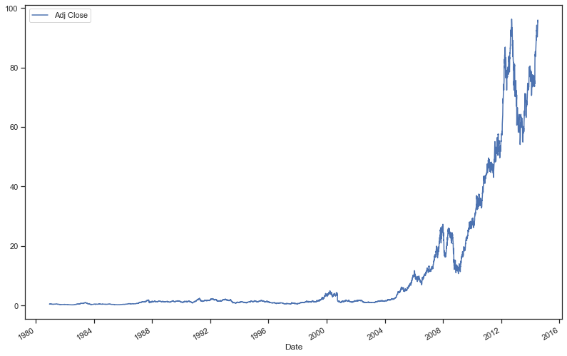

```python
apple.plot(y='Adj Close',figsize=(13.5,9))
```

## The below exercises (77-80) required to use Online_Retail.csv file

### 77. Import the dataset from this Online_Retail.csv and assign it to a variable called online_rt

```python
online_rt=pd.read_csv("D:\\personal\\nimisha\\Online_Retail.csv", encoding='windows-1252')
online_rt
```

|  | InvoiceNo | StockCode | Description | Quantity | InvoiceDate | UnitPrice | CustomerID | Country |
| --- | --- | --- | --- | --- | --- | --- | --- | --- |
| 0 | 536365 | 85123A | WHITE HANGING HEART T-LIGHT HOLDER | 6 | 12/1/10 8:26 | 2.55 | 17850.0 | United Kingdom |
| 1 | 536365 | 71053 | WHITE METAL LANTERN | 6 | 12/1/10 8:26 | 3.39 | 17850.0 | United Kingdom |
| 2 | 536365 | 84406B | CREAM CUPID HEARTS COAT HANGER | 8 | 12/1/10 8:26 | 2.75 | 17850.0 | United Kingdom |
| 3 | 536365 | 84029G | KNITTED UNION FLAG HOT WATER BOTTLE | 6 | 12/1/10 8:26 | 3.39 | 17850.0 | United Kingdom |
| 4 | 536365 | 84029E | RED WOOLLY HOTTIE WHITE HEART. | 6 | 12/1/10 8:26 | 3.39 | 17850.0 | United Kingdom |
| ... | ... | ... | ... | ... | ... | ... | ... | ... |
| 541904 | 581587 | 22613 | PACK OF 20 SPACEBOY NAPKINS | 12 | 12/9/11 12:50 | 0.85 | 12680.0 | France |
| 541905 | 581587 | 22899 | CHILDREN'S APRON DOLLY GIRL | 6 | 12/9/11 12:50 | 2.10 | 12680.0 | France |
| 541906 | 581587 | 23254 | CHILDRENS CUTLERY DOLLY GIRL | 4 | 12/9/11 12:50 | 4.15 | 12680.0 | France |
| 541907 | 581587 | 23255 | CHILDRENS CUTLERY CIRCUS PARADE | 4 | 12/9/11 12:50 | 4.15 | 12680.0 | France |
| 541908 | 581587 | 22138 | BAKING SET 9 PIECE RETROSPOT | 3 | 12/9/11 12:50 | 4.95 | 12680.0 | France |

541909 rows × 8 columns

### 78. Create a barchart with the 10 countries that have the most 'Quantity' ordered except UK

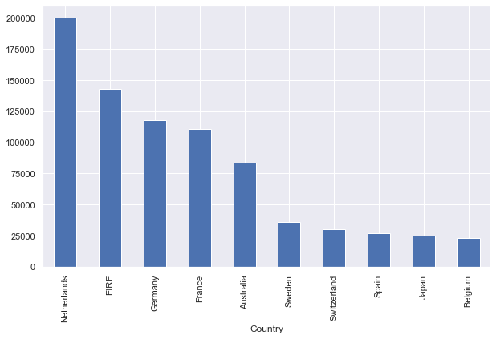

```python
online_rt.groupby('Country').Quantity.sum().sort_values(ascending =False).drop('United Kingdom').head(10).plot(kind='bar')
```

### 79. Exclude negative Quatity entries

```python
online_rt= online_rt[online_rt['Quantity'] >= 0]
online_rt
```

|  | InvoiceNo | StockCode | Description | Quantity | InvoiceDate | UnitPrice | CustomerID | Country |
| --- | --- | --- | --- | --- | --- | --- | --- | --- |
| 0 | 536365 | 85123A | WHITE HANGING HEART T-LIGHT HOLDER | 6 | 12/1/10 8:26 | 2.55 | 17850.0 | United Kingdom |
| 1 | 536365 | 71053 | WHITE METAL LANTERN | 6 | 12/1/10 8:26 | 3.39 | 17850.0 | United Kingdom |
| 2 | 536365 | 84406B | CREAM CUPID HEARTS COAT HANGER | 8 | 12/1/10 8:26 | 2.75 | 17850.0 | United Kingdom |
| 3 | 536365 | 84029G | KNITTED UNION FLAG HOT WATER BOTTLE | 6 | 12/1/10 8:26 | 3.39 | 17850.0 | United Kingdom |
| 4 | 536365 | 84029E | RED WOOLLY HOTTIE WHITE HEART. | 6 | 12/1/10 8:26 | 3.39 | 17850.0 | United Kingdom |
| ... | ... | ... | ... | ... | ... | ... | ... | ... |
| 541904 | 581587 | 22613 | PACK OF 20 SPACEBOY NAPKINS | 12 | 12/9/11 12:50 | 0.85 | 12680.0 | France |
| 541905 | 581587 | 22899 | CHILDREN'S APRON DOLLY GIRL | 6 | 12/9/11 12:50 | 2.10 | 12680.0 | France |
| 541906 | 581587 | 23254 | CHILDRENS CUTLERY DOLLY GIRL | 4 | 12/9/11 12:50 | 4.15 | 12680.0 | France |
| 541907 | 581587 | 23255 | CHILDRENS CUTLERY CIRCUS PARADE | 4 | 12/9/11 12:50 | 4.15 | 12680.0 | France |
| 541908 | 581587 | 22138 | BAKING SET 9 PIECE RETROSPOT | 3 | 12/9/11 12:50 | 4.95 | 12680.0 | France |

531285 rows × 8 columns

### 80. Create a scatterplot with the Quantity per UnitPrice by CustomerID for the top 3 Countries

Hint: First we need to find top-3 countries based on revenue, then create scater plot between Quantity and Unitprice for each country separately

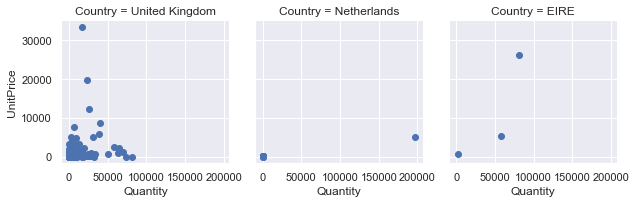

```python
sns.set(rc={'figure.figsize': (12, 8)})
customers = online_rt.groupby(['CustomerID','Country']).sum()
customers = customers[customers.UnitPrice > 0]
customers['Country'] = customers.index.get_level_values(1) #getting value of index(1) in the column country
top_countries =  ['United Kingdom', 'Netherlands', 'EIRE']
customers = customers[customers['Country'].isin(top_countries)]
g = sns.FacetGrid(customers, col="Country")
g.map(plt.scatter, "Quantity", "UnitPrice", alpha=1)
```

## The below exercises (81-90) required to use FMCG_Company_Data_2019.csv file

### 81. Import the dataset FMCG_Company_Data_2019.csv and assign it to a variable called company_data

```python
company_data=pd.read_csv('D:\Learning\\Nimisha\Basic Data Manipulation - Visualization Exercise\\FMCG_Company_Data_2019.csv')
company_data
```

|  | Month | FaceCream | FaceWash | ToothPaste | Soap | Shampo | Moisturizer | Total_Units | Total_Revenue | Total_Profit |
| --- | --- | --- | --- | --- | --- | --- | --- | --- | --- | --- |
| 0 | Jan-19 | 2500 | 1500 | 5200 | 9200 | 1200 | 1500 | 21100 | 3584890 | 211000 |
| 1 | Feb-19 | 2630 | 1200 | 5100 | 6100 | 2100 | 1200 | 18330 | 2864979 | 183300 |
| 2 | Mar-19 | 2140 | 1340 | 4550 | 9550 | 3550 | 1340 | 22470 | 4058082 | 224700 |
| 3 | Apr-19 | 3400 | 1130 | 5870 | 8870 | 1870 | 1130 | 22270 | 2890646 | 222700 |
| 4 | May-19 | 3600 | 1740 | 4560 | 7760 | 1560 | 1740 | 20960 | 2997280 | 209600 |
| 5 | Jun-19 | 2760 | 1555 | 4890 | 7490 | 1890 | 1555 | 20140 | 2857866 | 201400 |
| 6 | Jul-19 | 2980 | 1120 | 4780 | 8980 | 1780 | 1120 | 29550 | 5735655 | 295500 |
| 7 | Aug-19 | 3700 | 1400 | 5860 | 9960 | 2860 | 1400 | 36140 | 5196932 | 361400 |
| 8 | Sep-19 | 3540 | 1780 | 6100 | 8100 | 2100 | 1780 | 23400 | 3060720 | 234000 |
| 9 | Oct-19 | 1990 | 1890 | 8300 | 10300 | 2300 | 1890 | 26670 | 4661916 | 266700 |
| 10 | Nov-19 | 2340 | 2100 | 7300 | 13300 | 2400 | 2100 | 41280 | 6794688 | 412800 |
| 11 | Dec-19 | 2900 | 1760 | 7400 | 14400 | 1800 | 1760 | 30020 | 3770512 | 300200 |

### 82. Create line chart for Total Revenue of all months with following properties

- X label name = Month
- Y label name = Total Revenue

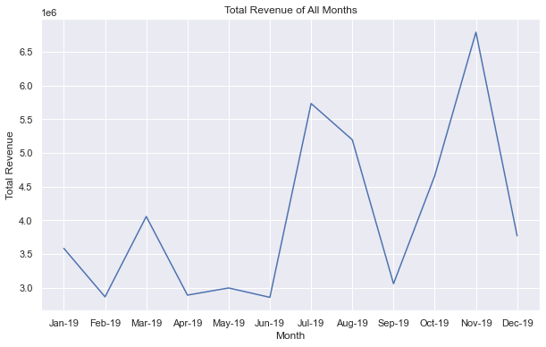

```python
sns.set(rc={'figure.figsize': (10, 6)})
sns.lineplot(x='Month',y='Total_Revenue', data=company_data)

plt.xlabel('Month')
plt.ylabel('Total Revenue')
plt.title('Total Revenue of All Months')
plt.show()
```

### 83. Create line chart for Total Units of all months with following properties

- X label name = Month
- Y label name = Total Units
- Line Style dotted and Line-color should be red
- Show legend at the lower right location.

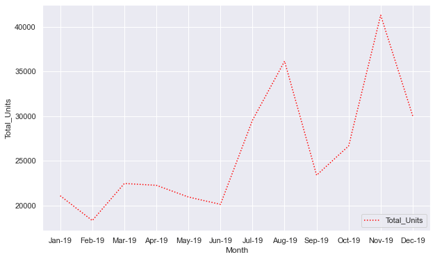

```python
sns.set(rc={'figure.figsize': (10, 6)})
sns.lineplot(x=company_data.Month,y=company_data.Total_Units, linestyle=':', linewidth=1.5, color='red')
plt.legend(['Total_Units'],loc='lower right')
plt.show()
```

### 84. Read all product sales data (Facecream, FaceWash, Toothpaste, Soap, Shampo, Moisturizer) and show it using a multiline plot

- Display the number of units sold per month for each product using multiline plots. (i.e., Separate Plotline for each product ).

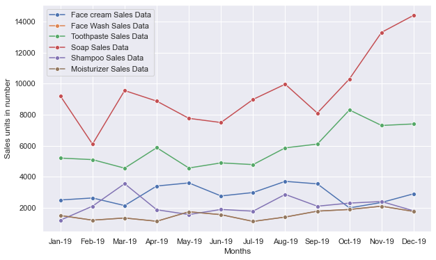

```python
sns.set(rc={'figure.figsize': (10, 6)})
sns.lineplot(x=company_data.Month,y=company_data.FaceCream, linestyle='-', label="Face cream Sales Data", marker='o' )
sns.lineplot(x=company_data.Month,y=company_data.FaceWash, linestyle='-', label="Face Wash Sales Data", marker='o' )
sns.lineplot(x=company_data.Month,y=company_data.ToothPaste, linestyle='-', label="Toothpaste Sales Data", marker='o' )
sns.lineplot(x=company_data.Month,y=company_data.Soap, linestyle='-', label="Soap Sales Data", marker='o' )
sns.lineplot(x=company_data.Month,y=company_data.Shampo, linestyle='-', label="Shampoo Sales Data", marker='o' )
sns.lineplot(x=company_data.Month,y=company_data.Moisturizer, linestyle='-', label="Moisturizer Sales Data", marker='o' )
plt.xlabel("Months")
plt.ylabel("Sales units in number")
plt.legend(loc=2)
plt.show()
```

### 85. Create Bar Chart for soap of all months and Save the chart in folder

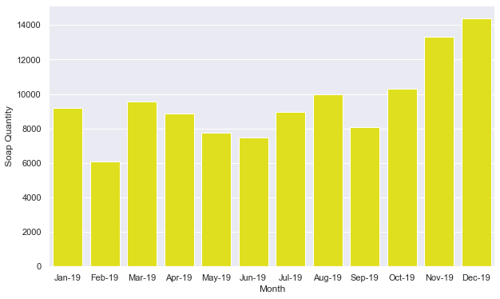

```python
sns.barplot(x=company_data.Month, y=company_data.Soap,color='Yellow')
plt.xlabel('Month')
plt.ylabel('Soap Quantity')
folder_path='D:\\Learning'
file_name='Soap_chart.png'
plt.savefig(folder_path + file_name)
plt.show()
```

### 86. Create Stacked Bar Chart for Soap, Shampo, ToothPaste for each month

The bar chart should display the number of units sold per month for each product. Add a separate bar for each product in the same chart.

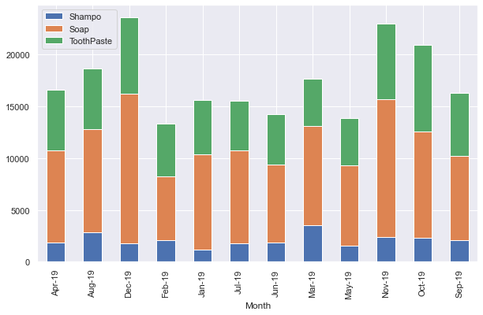

```python
sum1=company_data.pivot_table(index='Month',values=['ToothPaste','Soap','Shampo'])
sum1.plot(kind='bar',stacked=True)
```

### 87. Create Histogram for Total Revenue

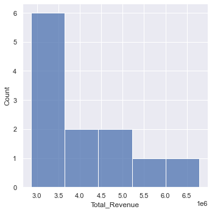

```python
sns.displot(company_data.Total_Revenue,kind='hist')
```

### 88. Calculate total sales data (quantity) for 2019 for each product and show it using a Pie chart. Understand percentage contribution from each product

[figure not shown]

```python
sum2=company_data.loc[ :,['FaceCream','FaceWash','ToothPaste','Soap','Shampo','Moisturizer']].sum()
sum2.plot(kind='pie',label='Sale')
```

### 89. Create line plots for Soap & Facewash of all months in a single plot using Subplot

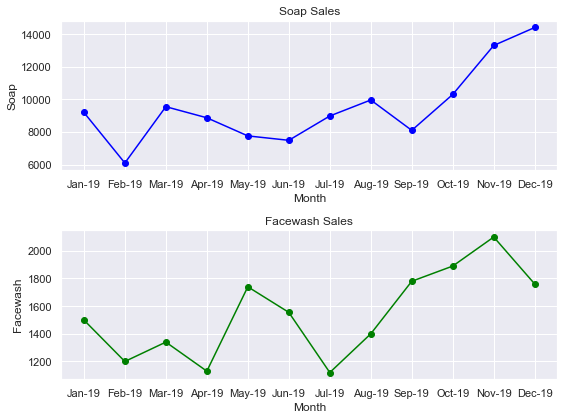

```python
fig, axes = plt.subplots(nrows=2, ncols=1, figsize=(8, 6))

axes[0].plot(company_data['Month'], company_data['Soap'], marker='o', linestyle='-', color='blue')
axes[0].set_xlabel('Month')
axes[0].set_ylabel('Soap')
axes[0].set_title('Soap Sales')

axes[1].plot(company_data['Month'], company_data['FaceWash'], marker='o', linestyle='-', color='green')
axes[1].set_xlabel('Month')
axes[1].set_ylabel('Facewash')
axes[1].set_title('Facewash Sales')

plt.tight_layout()
```

### 90. Create Box Plot for Total Profit variable

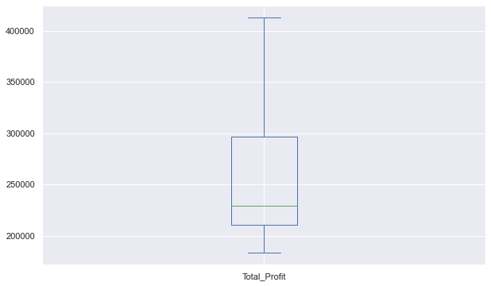

```python
company_data.Total_Profit.plot(kind='box')
```